# ОТЧЕТ О ВЫПОЛНЕНИИ ИНДИВИДУАЛЬНОГО ПРОЕКТА. ЭТАП №1

Курс “Операционные Системы”

Лихтенштейн А.А. , НКАбд-03-22

Российский университет дружбы народов, Москва, Россия

25 февраля 2023

## Докладчик

- Лихтенштейн Алина Алексеевна
- студент группы НКАбд-03-22
- кафедры Компьютерные и информационные науки
- Российский университет дружбы народов
- 1132229533@pfur.ru

## Цели и задачи

1. Установить необходимое программное обеспечение.
2. Скачать шаблон темы сайта.
3. Разместить его на хостинге git.
4. Установить параметр для URLs сайта.
5. Разместить заготовку сайта на Github pages.

# Выполнение лабораторной работы

## Скачивание архива

Скачиваем архив hugo_extended_0.110.0_Linux-64bit.tar.gz

[figure not shown]

Скачивание архива с исходным файлом hugo

## Создание директории в домашнем каталоге. Перенос исходного файла hugo

Создаем в домашнем каталоге папку bin и переносим исходный файл hugo в каталог ~/bin

[figure not shown]

## Создание репозитория “blog”

Создаем репозиторий с именем “blog” по шаблону wowchemy/starter-hugo-academic

[figure not shown]

Создание репозитория “blog”

## Переход в рабочую директорию и клонирование репозитория “blog”]

Переходим в каталог, где располагаются все наши репозитории, связанные с выполнением лабораторных работ и клонируем созданный репозиторий “blog” в ~/work

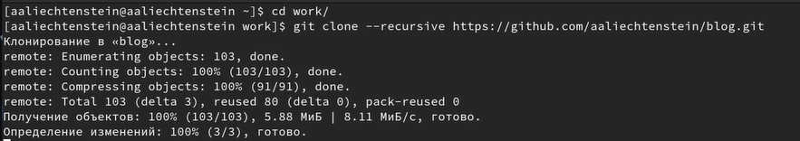

Переход в рабочую директорию и клонирование репозитория “blog”

## Команда ~/bin/hugo server и локальный адрес

Выполняем команду ~/bin/hugo server и с помощью полученного локального адреса переходим на веб-сайт

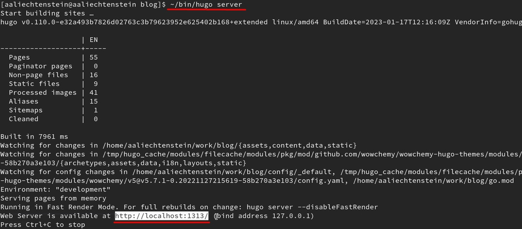

Команда ~/bin/hugo server и локальный адрес

## Команда ~/bin/hugo server и локальный адрес

[figure not shown]

Локальный веб-сайт

## Создание репозитория aaliechtenstein.github.io

Создаем репозиторий с именем “aaliechtenstein.github.io”

[figure not shown]

Создание репозитория “aaliechtenstein.github.io”

## Клонирование репозитория aaliechtenstein.github.io

Клонируем созданный репозиторий в ~/work

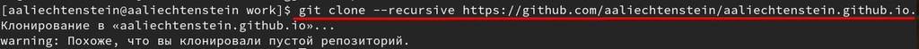

Клонирование репозитория “aaliechtenstein.github.io”

## Создание ветки main

Переходим в репозиторий “aaliechtenstein.github.io” и создаем ветку “main”

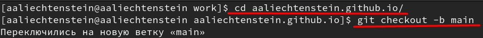

Создание ветки main

## Создание файла README.md. Отправка всех изменений на сервер

Создаем файл README.md и отправляем изменения на сервер репозитория

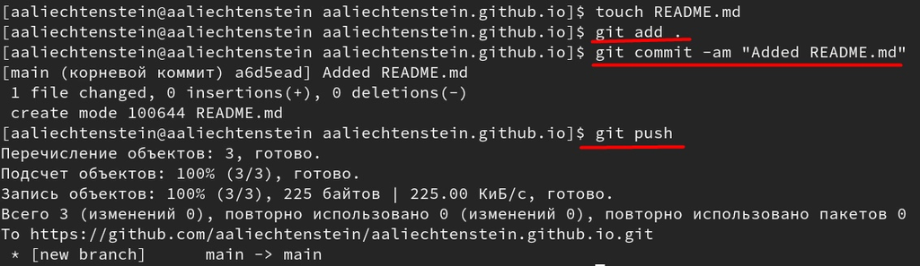

Создание файла README.md. Отправка изменений на сервер

## Комментирование каталога “public” в файле “.gitignore”

С помощью mcedit закомментируем каталог “public” в файле “.gitignore” репозитория “blog”

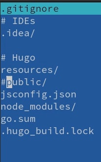

Комментирование каталога “public” в файле “.gitignore”

## Подключение модуль-директории

Подключаем к репозиторию “aaliechtenstein.github.io” модуль-директории “public”

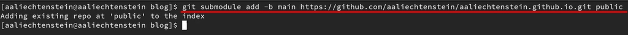

Подключение модуль-директории “public”

## Запуск исполняемого файла hugo

Запуск исполняемого файла hugo командой ~/bin/hugo в репозитории “blog”

[figure not shown]

Запуск исполняемого файла hugo

## Проверка соединения репозиториев

Проверим, соединены ли репозитории “blog” и “aaliechtenstein.github.io”

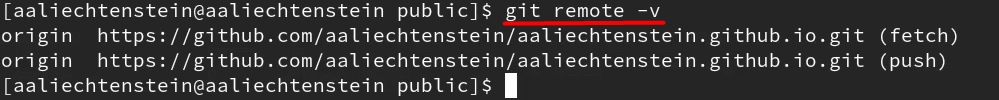

Проверка соединения репозиториев

## Отправка всех изменений на сервер

Отправим все изменения на сервер

## Проверка работоспособности сайта

Проверка работоспособности сайта по публичному адресу на основной ОС

[figure not shown]

Проверка работоспособности сайта